# 20200918_Pathak_Vinayak_HW2

## Exploratory Data Analysis and Data Preprocessing

1. From the same heart disease dataset in the file “heart_disease_df.csv”, create a new dataframe named “heart_df” that contains information on the subjects’ age, sex, resting blood pressure (trestbps), serum cholesterol level (chol), maximum heart rate (thalach), ST depression induced by exercise relative to rest (oldpeak) as well as the new column “diagnosed” in TRUE/FALSE. This is the dataset you worked with in the last HW, and information of this dataset (including all column names) is available at the website: https://archive.ics.uci.edu/ml/datasets/Heart+Disease. (6 points)

```r
heart_data <-read.csv(file="heart_disease_df.csv", header=TRUE)
```

```r
heart_df <-heart_data %>% select(age, sex, trestbps, chol, thalach, oldpeak, diagnosed)
```

2. Cast all columns into the most sensible variable type, e.g., “age” should be an integer, “sex” should be a factor, and “diagnosed” should be a logical. (4 points)

```r
heart_df["age"]<-as.integer(heart_data[["age"]])
```

```r
heart_df["chol"]<-as.integer(heart_data[["chol"]])
```

```r
heart_df["thalach"]<-as.integer(heart_data[["thalach"]])
```

```r
heart_df["trestbps"]<-as.integer(heart_data[["trestbps"]])
```

```r
heart_df["oldpeak"]<-as.numeric(heart_data[["oldpeak"]])
```

```r
heart_df["sex"]<-factor(heart_data[["sex"]], levels=c("1", "0"), labels=c("M","F"))
#This is later on changed back to integer
```

```r
heart_df["diagnosed"]<-as.logical(heart_data[["diagnosed"]])
```

3. Using ggplot and the grid drawing method of your choice, draw a 2-by-2 grid of 4 density histograms with the density curves overlaid on the same plot. Do this for **resting blood pressure**, **serum cholesterol level**, **maximum heart rate** and **ST depression induced by exercise relative to rest**.I recommend using the library “patchwork” or “gridExtra” for making the 4-plot grid. Label your axes and legend appropriately for full credit. You should also choose a suitable histogram bin width for each variable and explain why you made that choice. (10 points)

```r
t1 <- ggplot(heart_df, aes(x=trestbps))+geom_histogram(aes(y=..density..), position="identity", alpha=0.5, binwidth=10, fill="white", color="brown")+geom_density()+labs(x="Resting Blood Pressure(mm/Hg)", y="Density")+ theme(legend.position="right")
```

```r
t2 <- ggplot(heart_df, aes(x=chol))+geom_histogram(aes(y=..density..), position="identity", alpha=0.5, binwidth=10, fill="white", color="brown")+geom_density()+labs(x="Cholesterol(mg/dl)", y="Density")+ theme(legend.position="right")
```

```r
t3 <- ggplot(heart_df, aes(x=thalach))+geom_histogram(aes(y=..density..), position="identity", alpha=0.5, binwidth=10, fill="white", color="brown")+geom_density()+labs(x="Maximum heart Rate", y="Density")+ theme(legend.position="right")
```

```r
t4 <- ggplot(heart_df, aes(x=oldpeak))+geom_histogram(aes(y=..density..), position="identity", alpha=0.5, binwidth=0.2, fill="white", color="brown")+geom_density()+labs(x="ST deprs. induced by exercise rltv to rest", y="Density")+ theme(legend.position="right")
```

The above choice of binwidth allows the density curves to overlap appropriately over the histogram and show the appropriate distribuition

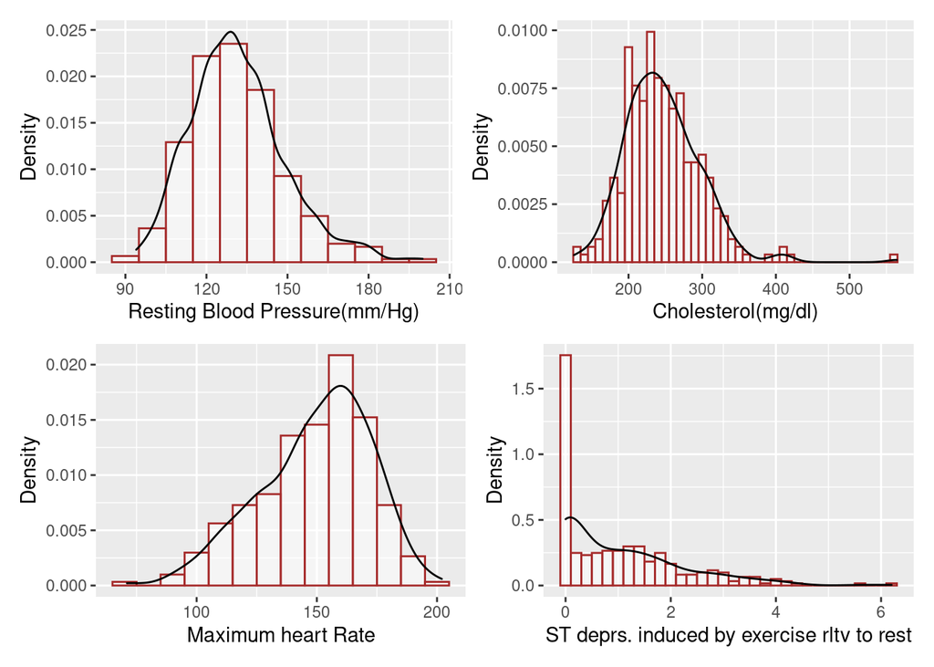

```r
plot((t1|t2)/(t3|t4))
```

4. Now using a similar 2 by 2 grid, overlay two separate density curves for the diseased and healthy groups, for each variable (feature) from question 3. For these figures, plot the just the density curve(without the density histogram bins). Add a vertical line for each of the two density curves on each plot at the mean value for that combined feature and diagnosis group. For example, in the first grid, which is row 1 and column 1 of the 2-by-2 grid, there should be two density plots drawn in two colors for the two different diagnosis groups (diagnosed = TRUE and diagnosed = FALSE). (20 points)

```r
mean1<-ddply(heart_df, "diagnosed", summarise, grp.mean = mean(trestbps))
mean2<-ddply(heart_df, "diagnosed", summarise, grp.mean = mean(chol))
mean3<-ddply(heart_df, "diagnosed", summarise, grp.mean = mean(thalach))
mean4<-ddply(heart_df, "diagnosed", summarise, grp.mean = mean(oldpeak))
```

```r
t11<-ggplot(heart_df, aes(x=trestbps, color=diagnosed)) +
  geom_density()+geom_vline(data=mean1, aes(xintercept=grp.mean, color=diagnosed),linetype="dashed")+labs(x="Resting Blood Pressure(mm/Hg)", y="Density")
t21<-ggplot(heart_df, aes(x=chol, color=diagnosed)) +
  geom_density()+geom_vline(data=mean2, aes(xintercept=grp.mean, color=diagnosed),linetype="dashed")+labs(x="Cholesterol (mg/dl)", y="Density")
t31<-ggplot(heart_df, aes(x=thalach, color=diagnosed)) +
  geom_density()+geom_vline(data=mean3, aes(xintercept=grp.mean, color=diagnosed),linetype="dashed")+labs(x="Maximum heart Rate", y="Density")
t41<-ggplot(heart_df, aes(x=oldpeak, color=diagnosed)) +
  geom_density()+geom_vline(data=mean4, aes(xintercept=grp.mean, color=diagnosed),linetype="dashed")+labs(x="ST depression induced by exercise relative to rest", y="Density")
```

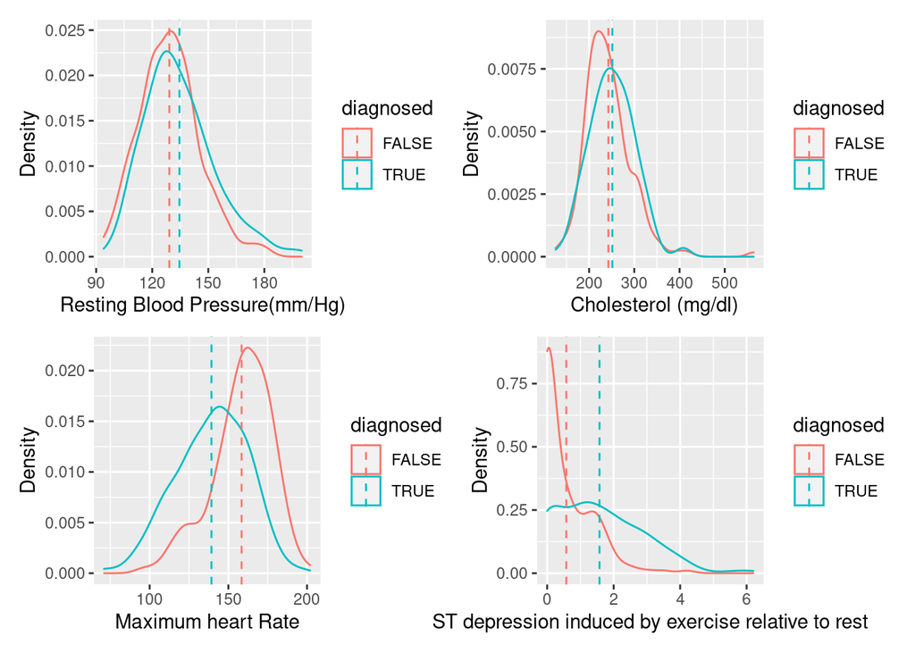

```r
(t11|t21)/(t31|t41)
```

5. What are your observations? E.g. Does any feature visually show a strong difference in means or in shape of the data between the two diagnosis groups? For each feature, which diagnosis group seems to have a higher average value? Clearly explain your answer to receive full mark. (5 points)

Answer 5. The patients which are diagnosed TRUE i.e. have a heart disease, have higher mean value of Resting Blood Pressure, Cholestrol and the ST depression induced by the exercise relative to rest. Whereas, their maximum heart rate is lower than the healthy individuals. While the data for healthy and unhealthy individuals almost overlap in the case of Resting Blood Pressure and Cholesterol with Diseased/Unhealthy indivduals(with heart. disease) having slightly higher mean values. For the Maximum heart rate and ST depression induced by exercise relative to rest, comparing the shape of the data of the healthy with the unhealthy group, it is significantly different. In the case of Maximum heart rate unhealthy indivduals have a significantly lower mean value than the healthy individuals. Whereas the cholestrol in diseased individual has higher mean value when compared to the healthy individuals. Also commenting on the skewnewss, Resting blood pressure , cholestrol and ST depression… have positive skewnness whereas Maximum heart rate has negative skewness.

6. By observing the histogram and density plots of all four predictors, answer the following questions for each of the predictors/variables:
1. Is the dataset for each predictor/variable skewed?
2. Does it have positive skewness or negative skewness? (Think about to question 5 in the section above.)
3. Compute the skewness using the definition from the lecture.
4. According to the criterion introduced in the lecture, is the dataset moderately skewed or highly skewed? (10 points)

```r
a<-heart_df$trestbps
b<-heart_df$chol
c<-heart_df$thalach
d<-heart_df$oldpeak
mean_1<-mean(a)
mean_2<-mean(b)
mean_3<-mean(c)
mean_4<-mean(d)

n1<-length(a)
n2<-length(b)
n3<-length(c)
n4<-length(d)

m1<- (1/n1)*sum('^'((a-mean_1), 3))
m2<- (1/n2)*sum('^'((b-mean_2), 3))
m3<- (1/n3)*sum('^'((c-mean_3), 3))
m4<- (1/n4)*sum('^'((d-mean_4), 3))

s1<- '^'((1/(n1-1))*(sum('^'((a-mean_1), 2))), 1.5)
s2<- '^'((1/(n2-1))*(sum('^'((b-mean_2), 2))), 1.5)
s3<- '^'((1/(n3-1))*(sum('^'((c-mean_3), 2))), 1.5)
s4<- '^'((1/(n4-1))*(sum('^'((d-mean_4), 2))), 1.5)

b1<-m1/s1
b2<-m2/s2
b3<-m3/s3
b4<-m4/s4
```

```r
if(class(heart_df$sex)!='integer')
heart_df$sex<-as.integer(as.logical(heart_df$sex=='M'))
```

```r
library(corrplot)
library(psych)
M <-mixedCor(heart_df)
```

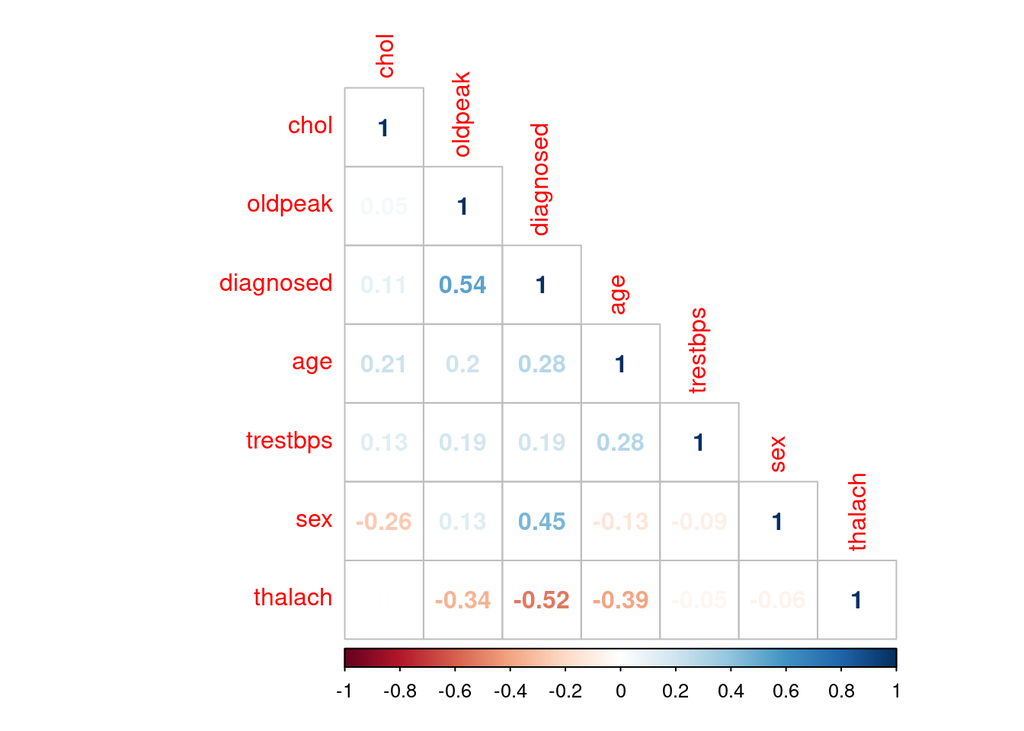

```r
corrplot(M$rho, method="number", type="lower", order="hclust")
```

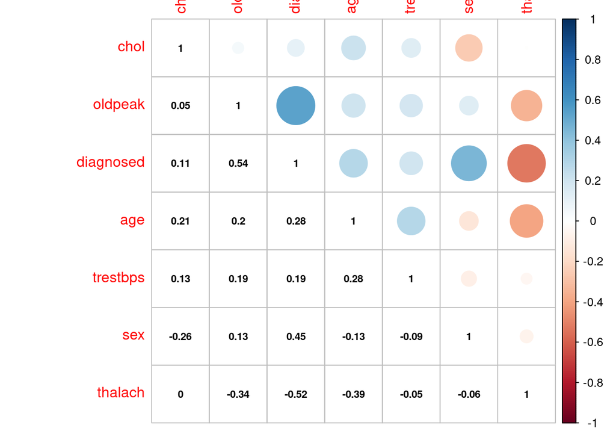

```r
#corrplot.mixed(M$rho, method="circle", type="upper", order="hclust")
corrplot.mixed(M$rho, lower.col = "black", upper="circle",number.cex = .7, order="hclust", diag="l", tl.pos="lt")
```

```r
#plot(heart_df$diagnosed, heart_df$oldpeak)
```

9. Perform winsorization on the **serum cholesterol level** dataset. Typically, you can decide a threshold (typically a specific range of percentiles) and replace all the data points outside of the threshold with the closest value from within the threshold. An example from Wikipedia may be a helpful demonstration: “a 90% winsorization would see all data below the 5th percentile set to the 5th percentile, and data above the 95th percentile set to the 95th percentile.” Conduct a 90% winsorization on the cholesterol level dataset and plot a histogram of the winsorized data. What is your observation? (5 points)

```r
#Defining the winsorisation percent
winsorisation_percent =10

winsor <- function (x , fraction=.05)
{ fraction = winsorisation_percent*(0.5)*(1/100)
   if(length(fraction) != 1 || fraction < 0 ||
         fraction > 0.5) {
      stop("Please enter the value of winsorisation percent less than 100'")
   }
   lim <- quantile(x, probs=c(fraction, 1-fraction))
   x[ x < lim[1] ] <- lim[1]
   x[ x > lim[2] ] <- lim[2]
   return(x)
}
xinit=heart_df$chol
xmod<-winsor(xinit, winsorisation_percent)
```

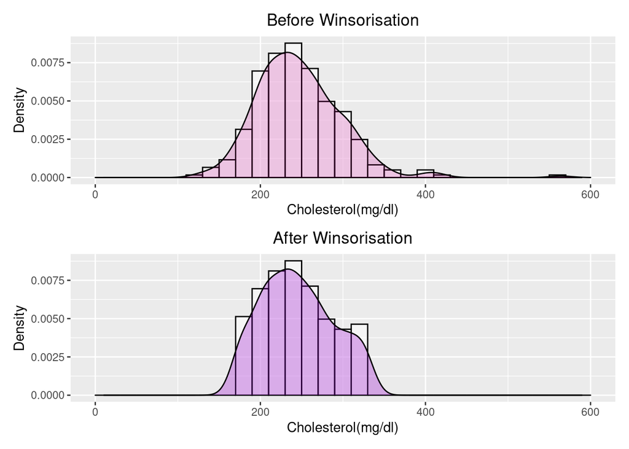

```r
t3 <- ggplot(heart_df, aes(x=xinit))+geom_histogram(aes(y=..density..), position="identity", alpha=0.5, binwidth=20, fill="white", color="black")+geom_density(fill="#CC0099",  alpha=0.2)+labs(x="Cholesterol(mg/dl)", y="Density")+xlim(0, 600)+ggtitle("Before Winsorisation")+theme(plot.title = element_text(hjust = 0.5))
dfchol <-data.frame(xmod)
t7 <- ggplot(dfchol, aes(x=xmod))+geom_histogram(aes(y=..density..), position="identity", alpha=0.5, binwidth=20, fill="white", color="black")+geom_density(fill="#9900CC",  alpha=0.3)+labs(x="Cholesterol(mg/dl)", y="Density")+xlim(0, 600)+ggtitle("After Winsorisation")+theme(plot.title = element_text(hjust = 0.5))
plot(t3/t7)
```

```r
dfchol["xinitlog"]<-data.frame(log(xinit+1))
```

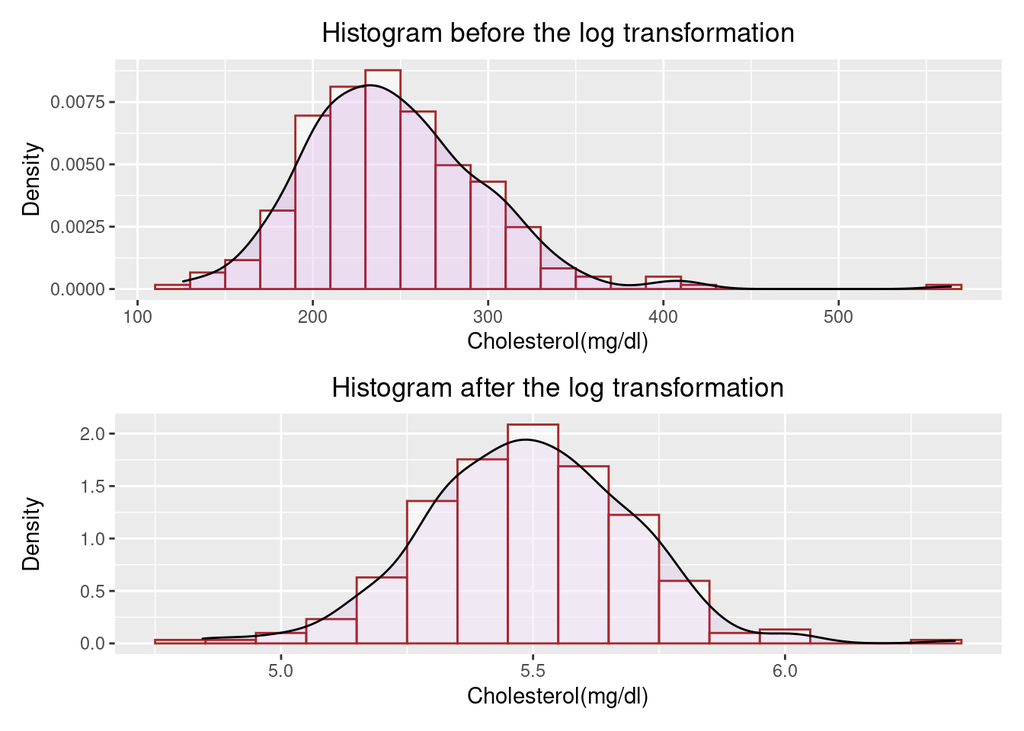

```r
plot5<-ggplot(dfchol, aes(x=xinit))+geom_histogram(aes(y=..density..), position="identity", alpha=0.5, binwidth=20, fill="white", color="brown")+labs(x="Cholesterol(mg/dl)", y="Density")+geom_density(fill="#9900CC",  alpha=0.1)+ggtitle("Histogram before the log transformation")+theme(plot.title = element_text(hjust=0.5))

plot6<-ggplot(dfchol, aes(x=xinitlog))+geom_histogram(aes(y=..density..), position="identity", alpha=0.5, binwidth=0.1, fill="white", color="brown")+labs(x="Cholesterol(mg/dl)", y="Density")+geom_density(fill="#9900CC",  alpha=0.05)+ggtitle("Histogram after the log transformation")+theme(plot.title = element_text(hjust=0.5))
plot(plot5/plot6)
```

In the first case before logg transformation the data is positively skewed, whereas in the seconnd case the data almost centered around a mean value, and not skewed.